# Bank Marketing - Term Deposit Classification Model

TALL Machine Learning - Zheng (James) Lai, Iman Lau, Dung Tran

October 12, 2018

```r
library(ggplot2)
library(plyr)
library(dplyr)
library(Hmisc)
library(ggpubr)
library(DMwR)
library(caret)
library(pROC)
model_dir = "models"
data_dir = "data"
saved_models = list.files(model_dir)
for(file in saved_models) {
  load(paste(model_dir,file,sep="/"))
}
data=read.csv(paste(data_dir,"bank-additional-full.csv",sep="/"), header = TRUE, sep = ";")
```

## I. Introduction

The first assignment for the York Machine Learning course, *Machine Learning in Business Context* was to explore supervised machine learning algoritms. We chose a dataset from the UCI Machine Learning Repository, [Bank Marketing Data Set](https://archive.ics.uci.edu/ml/datasets/Bank+Marketing). This report follows the structures laid out in CRISP-DM methodology.

The GitHub repository for all the source code is located at the following link: https://github.com/DungTranGitHub/BankMarketing.

## II. Business Understanding

Banks often used direct marketing methods, such as telemarketing, in order to sell banking products to their customers. One such product is a term deposit. One piece of business domain knowledge that is useful to keep in mind is that a term deposit is a low-risk financial product.

When running a telemarketing campaign, each call costs a certain amount of money, with only some calls being successful. Each call would thus cost the bank money, and a model that could predict which customers are most likely to convert would enable the bank to more efficiently plan their marketing strategy.

As we lack specific knowledge on the cost of each call, and the amount of money that a conversion would bring in, we are running under the assumption that each call is sufficiently expensive that one would not want to call every client.

The objective of this model is to predict whether or not a customer will say yes to a term deposit. To determine how successful our model is, we are looking at the Return on Investment (ROI). A marketing campaign’s goal is to have a high number of conversions as well as to have a high ROI, so a model that can assess whether or not a customer is likely to convert would be valuable.

## III. Data Understanding

The following table shows the numeric attributes:

[output not shown]

While this table shows the categorical attributes:

| Attribute | Description |
| --- | --- |
| job | Type of job - 12 options, including “unknown” |
| marital | Marital status - 4 options, including “unknown,” where “divorced” means divorced or widowed |
| education | Education level - 8 options, including “unknown” |
| default | Does the client have credit in default? Yes or No, includes “unknown” |
| housing | Does the client have housing loan? Yes or No, includes “unknown” |
| loan | Does the client have personal loan? Yes or No, includes “unknown” |
| contact | Type of communication used to contact the client in this campaign - 2 options, “cellular”, “telephone” |
| month | Month of last contact |
| day_of_week | Day of week of last contact |
| poutcome | Outcome of the previous marketing campaign - “failure”, “nonexistent”, “success” |
| y | target variable, has the client subscribed a term deposit? binary: ‘yes’,‘no’ |

Secondly, although there are no missing values in the raw dataset, certain categorical attributes have “unknown” and “nonexistent” as an option. To see how many “unknown”/“nonexistent” we have in the data, we replace “unknown” with “NA” and print the number of “NA”s for each column. Also we replaced “999” in “pdays” with “NA”.

```r
data = read.csv(paste(data_dir,"bank-additional-full.csv",sep="/"), header = TRUE, sep = ";", na.strings = c("NA","","#NA","unknown","nonexistent"))
data[data$pdays==999,"pdays"] = NA
apply(data,2,function(x){sum(is.na(x))/length(x)*100})
```

```
##            age            job        marital      education        default
##      0.0000000      0.8012042      0.1942313      4.2026804     20.8725842
##        housing           loan        contact          month    day_of_week
##      2.4036127      2.4036127      0.0000000      0.0000000      0.0000000
##       duration       campaign          pdays       previous       poutcome
##      0.0000000      0.0000000     96.3217442      0.0000000     86.3431096
##   emp.var.rate cons.price.idx  cons.conf.idx      euribor3m    nr.employed
##      0.0000000      0.0000000      0.0000000      0.0000000      0.0000000
##              y
##      0.0000000
```

```r
# restore the data
data = read.csv(paste(data_dir,"bank-additional-full.csv",sep="/"), header = TRUE, sep = ";")
```

We can see that “pdays” and “poutcome” has particular high percentage of missing values(96% and 86% respectively). “default” also has about 20% missing values. We will come back to missing values in the next section.

Next we will dive deep into data exploration and preparation.

## IV. Data Exploration and Preparation

### (1) Visualizations for client-related attributes

These visuallizations serve as our first attempt to understand the influence over target variable (“y”) by various features. Two features need minor attentions in order to best present its significance. One is “age”, where we have cut the ages into different groups, with 10 years in each group, excepting the “teengagers,” and “seniors.” The other is “pdays” which has many “999” values, which indicates that the client was not previously contacted. This value was removed during visualization.

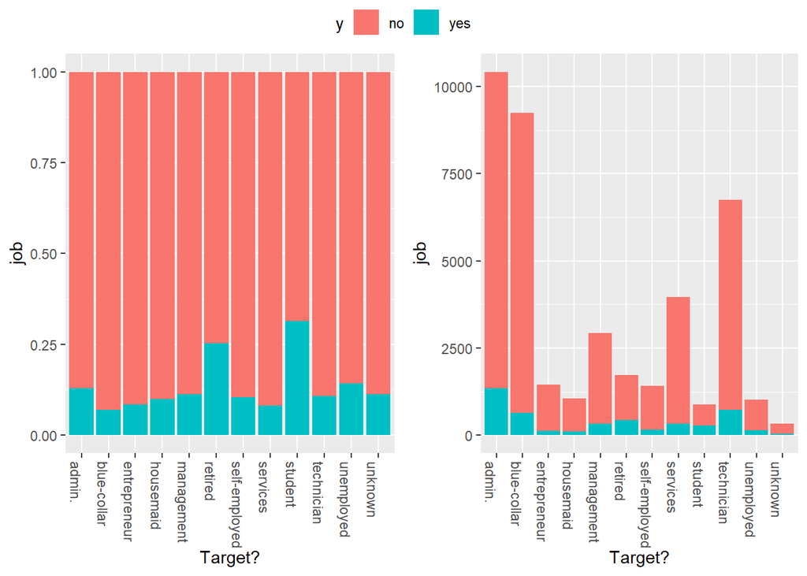

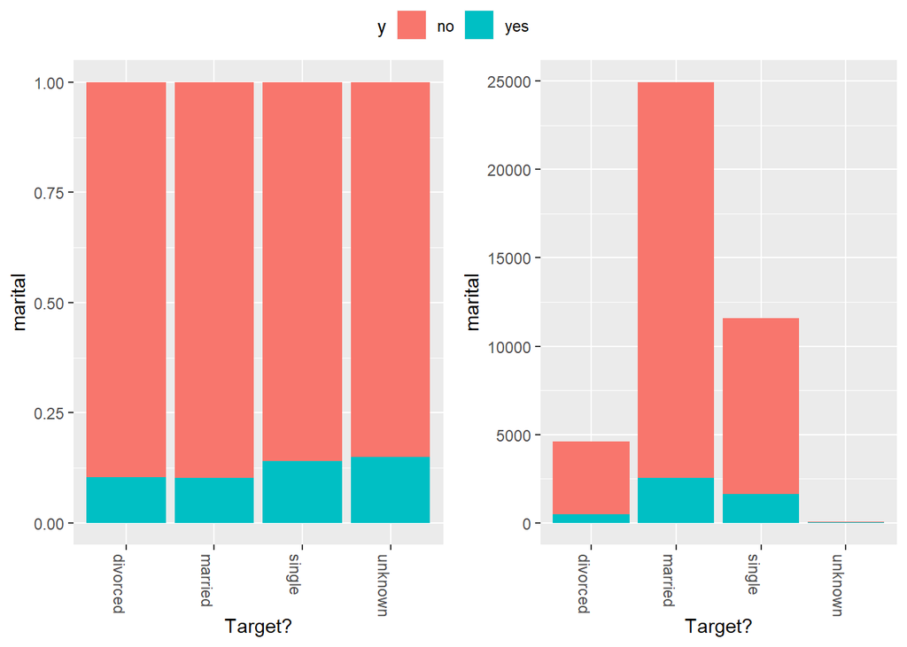

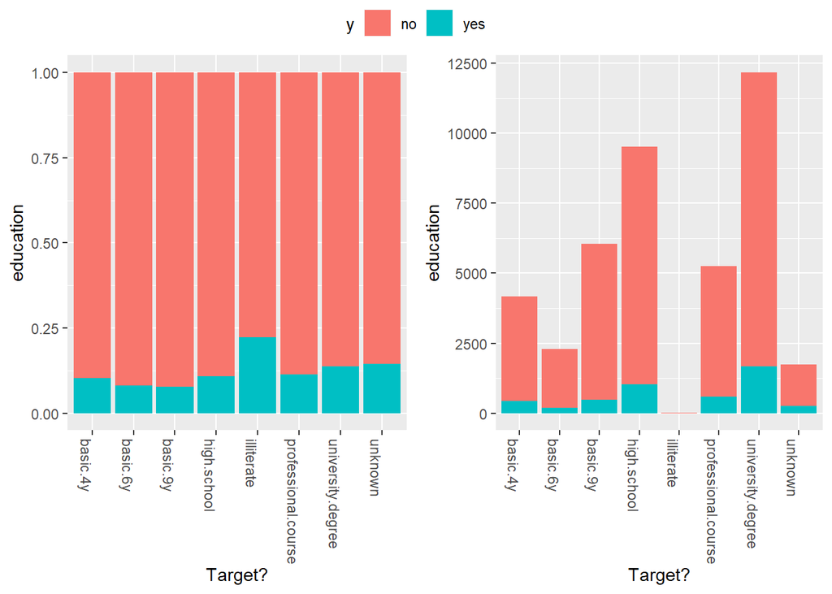

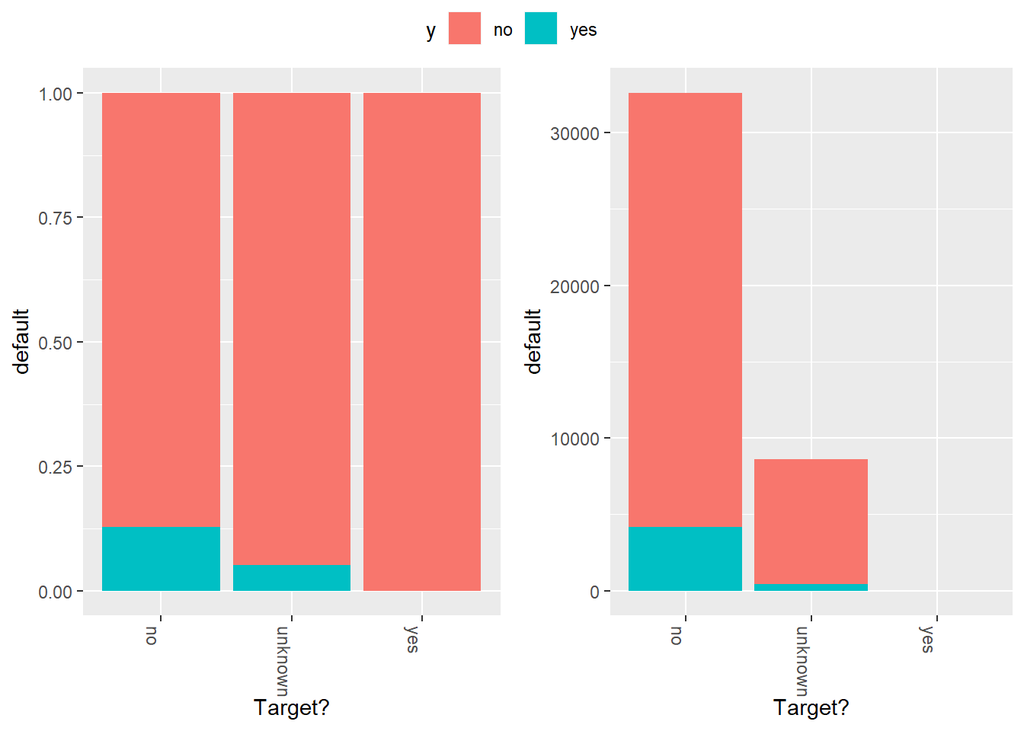

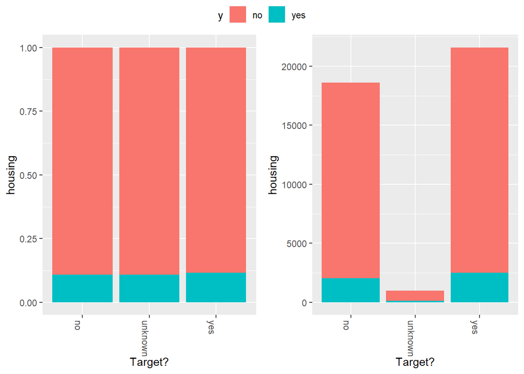

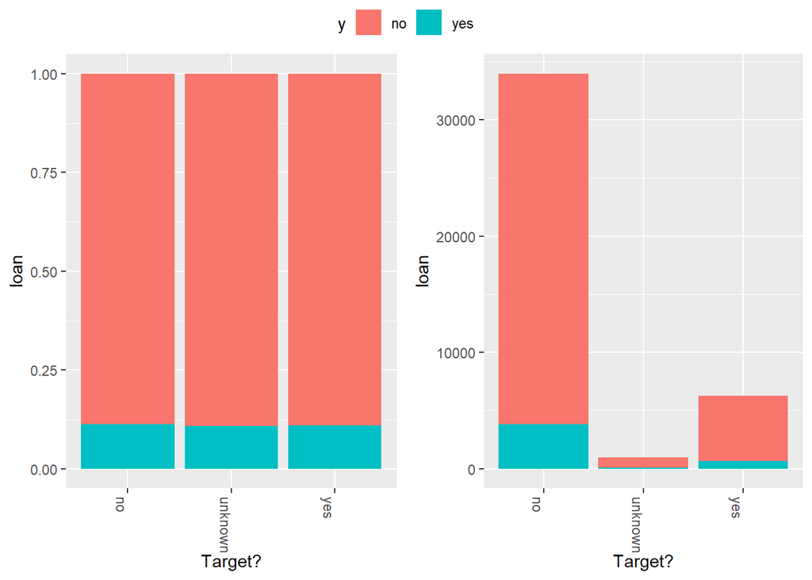

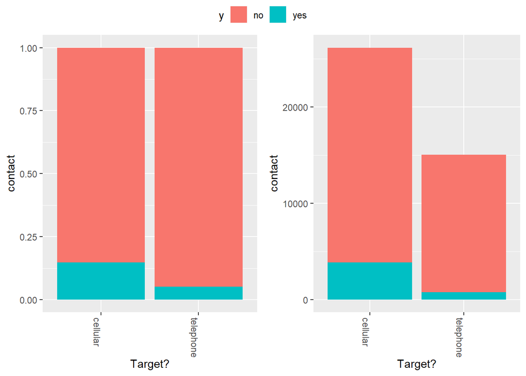

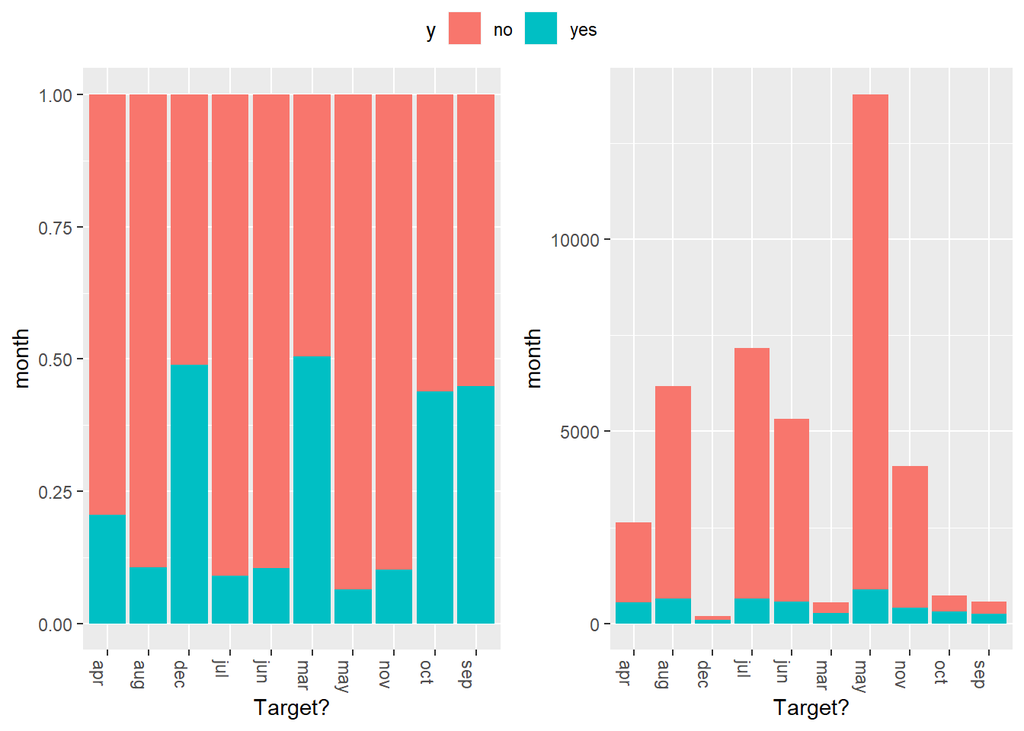

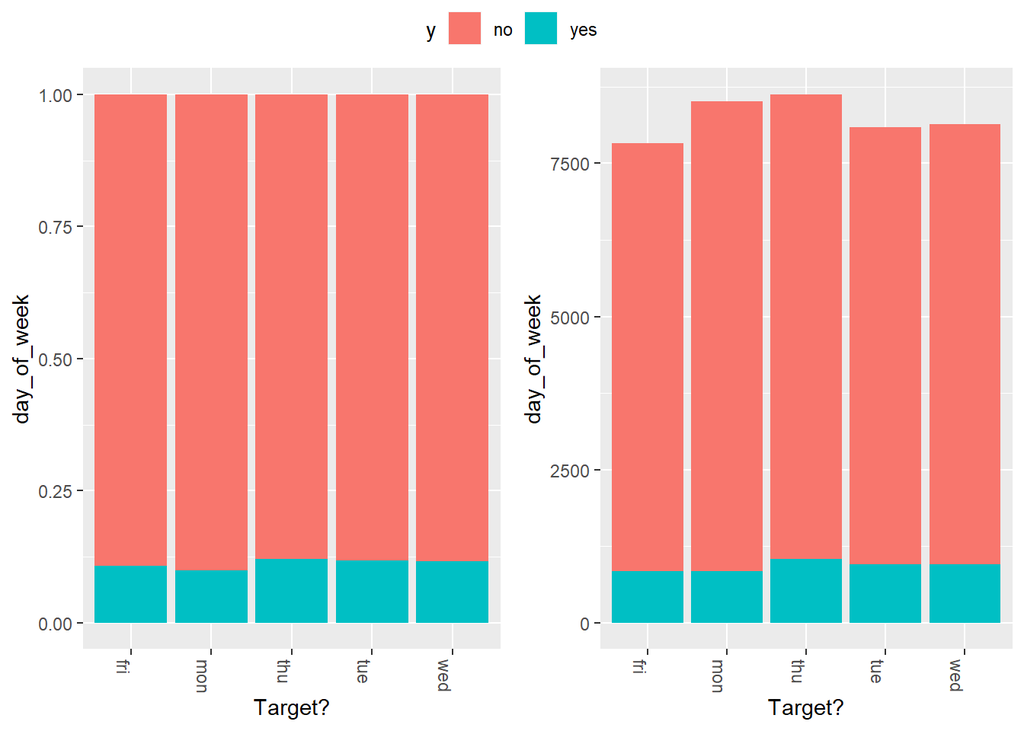

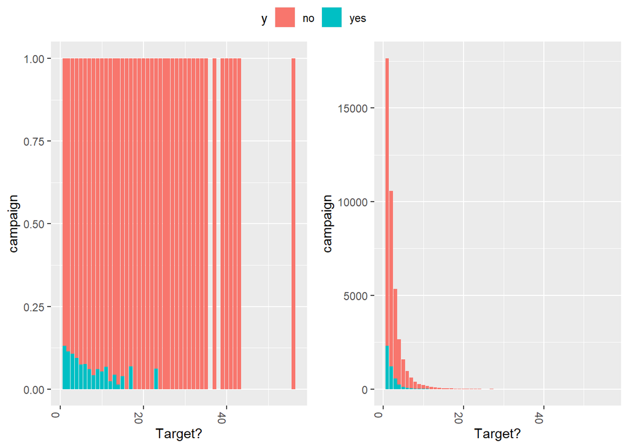

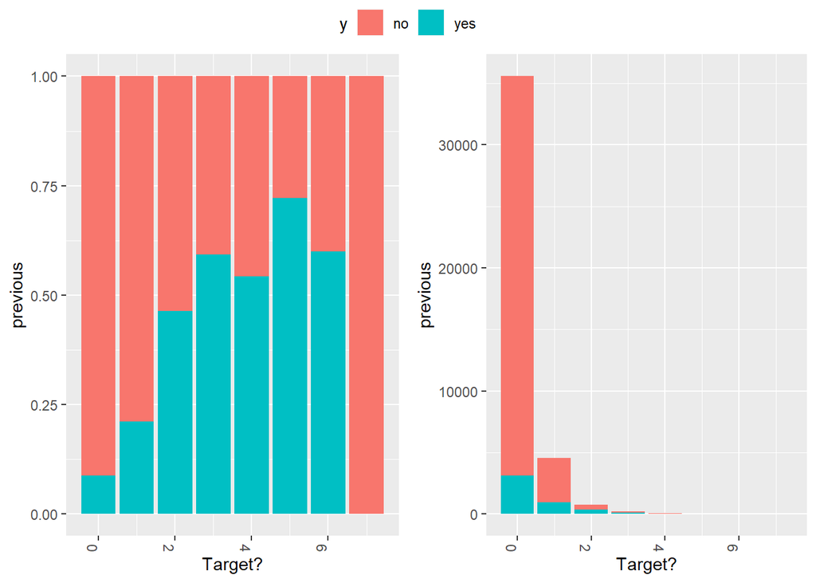

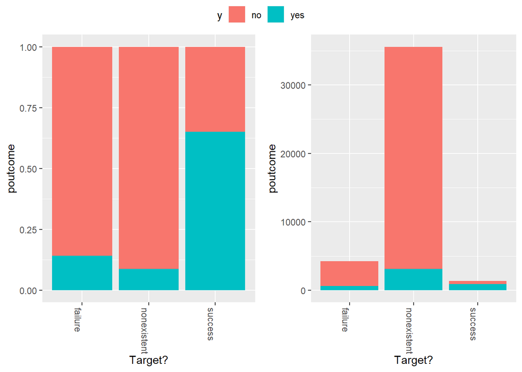

```r
library(ggplot2)
library(ggpubr)
for (col in c("job","marital","education","default","housing","loan","contact","month","day_of_week","campaign","previous","poutcome")) {
    p1 = ggplot(data, aes(data[,col], fill = y)) + geom_bar(position="fill") +
      labs(x = "Target?", y = col) +
      theme(axis.text.x=element_text(angle = -90, hjust = 0))
    p2 = ggplot(data, aes(data[,col], fill = y)) + geom_bar() +
      labs(x = "Target?", y = col) +
      theme(axis.text.x=element_text(angle = -90, hjust = 0))
    p3 = ggarrange(p1, p2, ncol = 2, nrow = 1, common.legend = TRUE)
    print(p3)
}
```

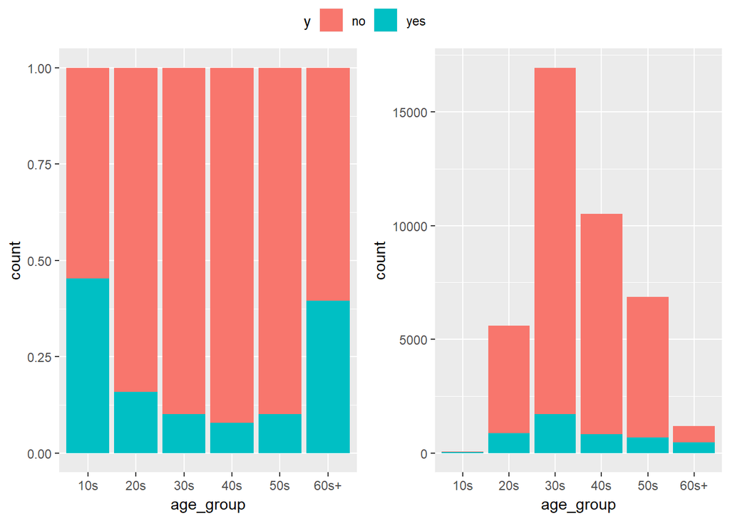

```r
# Age effect
data$age_group = cut2(data$age,c(20,30,40,50,60))
data$age_group = mapvalues(data$age_group, from = levels(data$age_group), to = c("10s", "20s", "30s", "40s", "50s", "60s+"))
p1 = ggplot(data,aes(x=age_group,fill=y)) + geom_bar(position="fill")
p2 = ggplot(data,aes(x=age_group,fill=y)) + geom_bar()
p3 = ggarrange(p1, p2, ncol = 2, nrow = 1, common.legend = TRUE)
print(p3)
```

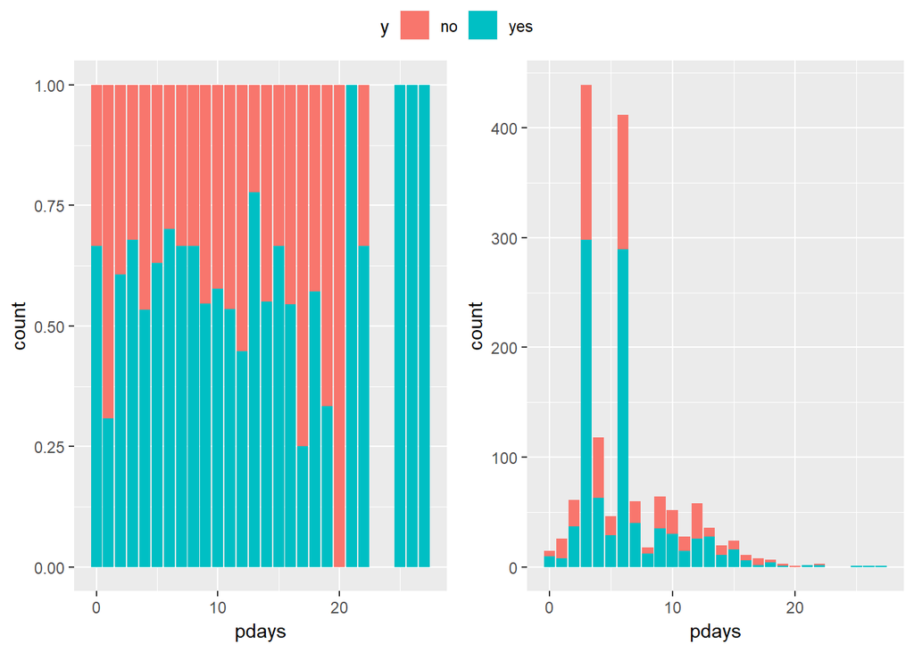

```r
# pdays
data[data$pdays == 999,]$pdays = NA
data = na.omit(data,pdays)
p1 = ggplot(data,aes(x=pdays,fill=y)) + geom_bar(position="fill")
p2 = ggplot(data,aes(x=pdays,fill=y)) + geom_bar()
p3 = ggarrange(p1, p2, ncol = 2, nrow = 1, common.legend = TRUE)
print(p3)
```

### (2) Visualizations for the social/economic attributes

After inspecting the attributes related to client’s personal situations, we now look at the effect from macro-economic factors.

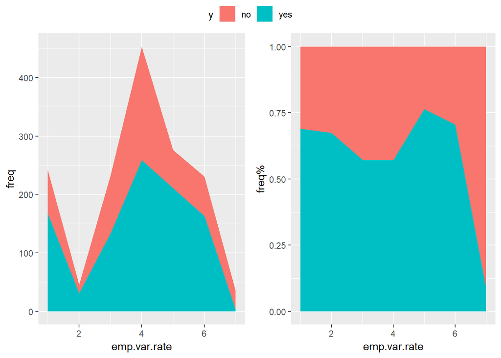

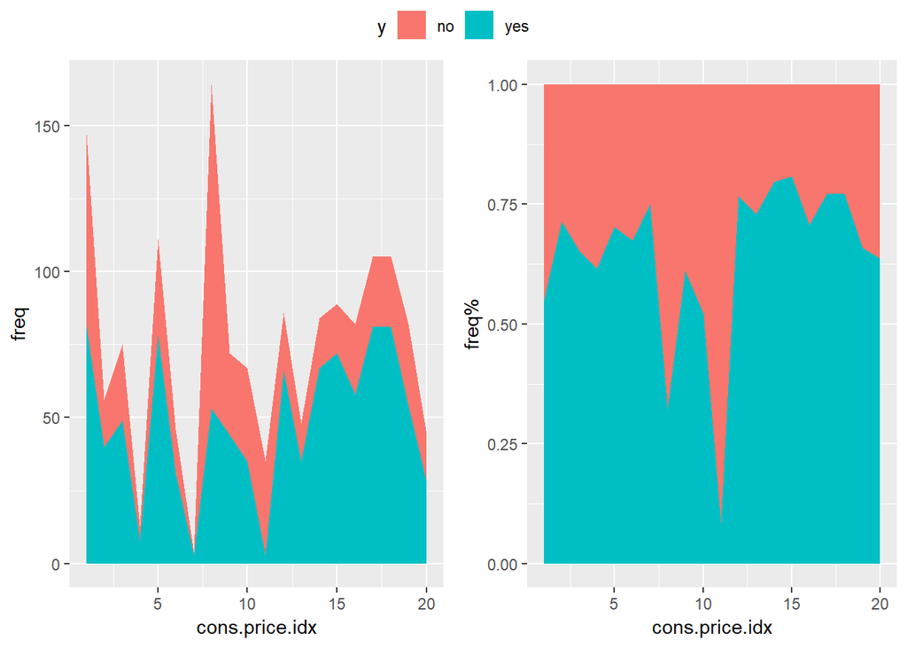

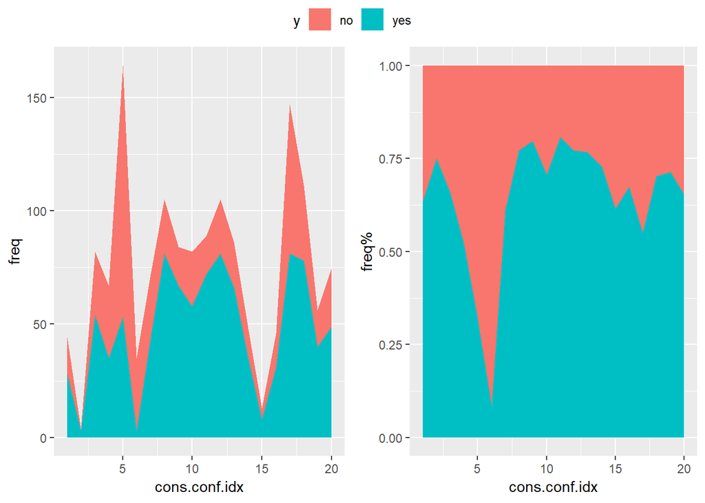

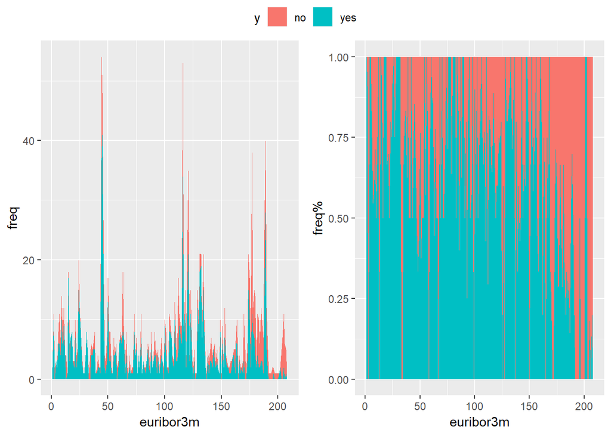

```r
for(colname in c("emp.var.rate", "cons.price.idx", "cons.conf.idx", "euribor3m")) {
  df_temp = data.frame(table(data[,colname],data$y))
  colnames(df_temp) =c(colname,"y","freq")
  df_temp[,colname] = as.numeric(df_temp[,colname])
  p1 = ggplot(df_temp, aes(x=df_temp[,colname], y=freq,fill=y)) + geom_area() +
    labs(x=colname,y="freq")
  df_temp = data.frame(prop.table(table(data[,colname],data$y),1))
  colnames(df_temp) =c(colname,"y","freq")
  df_temp[,colname] = as.numeric(df_temp[,colname])
  p2 = ggplot(df_temp, aes(x=df_temp[,colname], y=freq,fill=y)) + geom_area() +
    labs(x=colname,y="freq%")
  p3 = ggarrange(p1, p2, ncol = 2, nrow = 1, common.legend = TRUE)
  print(p3)
}
```

These visuals show that social and economic factors may have an effect on whether or not someone signs up for a term deposit. What is particularly interesting is the plots regarding “euribor3m”. The Euro Interbank Offered Rate [(Euribor)](https://en.wikipedia.org/wiki/Euribor), is a “daily reference rate, published by the European Money Markets Institute, based on the averaged interest rates at which Eurozone banks offer to lend unsecured funds to other banks in the euro wholesale money market (or interbank market)”. Interest rates rarely increase during a recession; in fact, the opposite tends to happen: as the economy contracts, [interest rates fall in tandem](https://www.investopedia.com/ask/answers/102015/do-interest-rates-increase-during-recession.asp#ixzz5TkhmrgLt). On the “euribor3m” plots, we can see that there is a rough trend that as “euribor3m” drops, the percentage of people who sign up for term deposit product actually increases. It also means our data would benefit by incoporating the macro-economic models.

These social/economic attributes can be binned to create a more even distribution, and to reduce the effect from noise on model generalization.

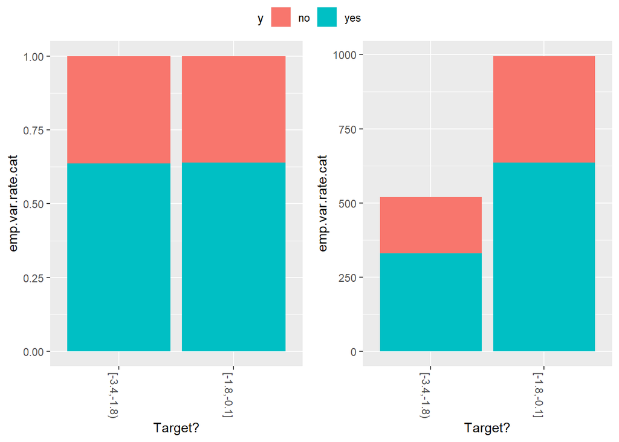

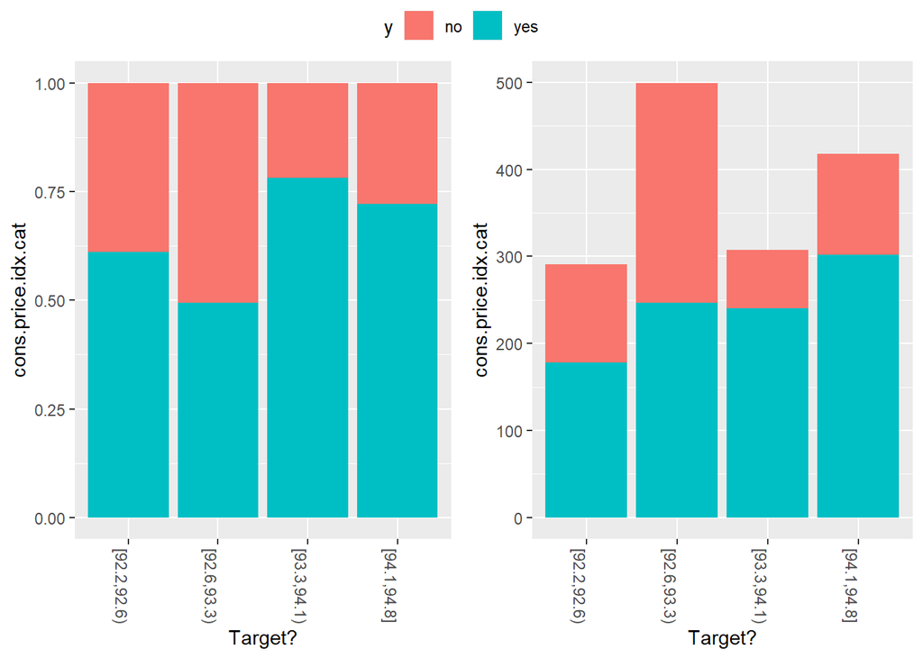

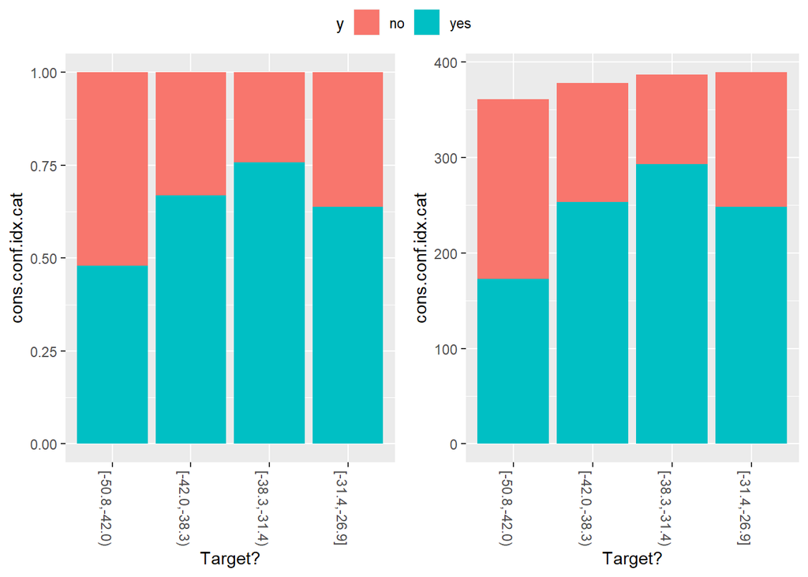

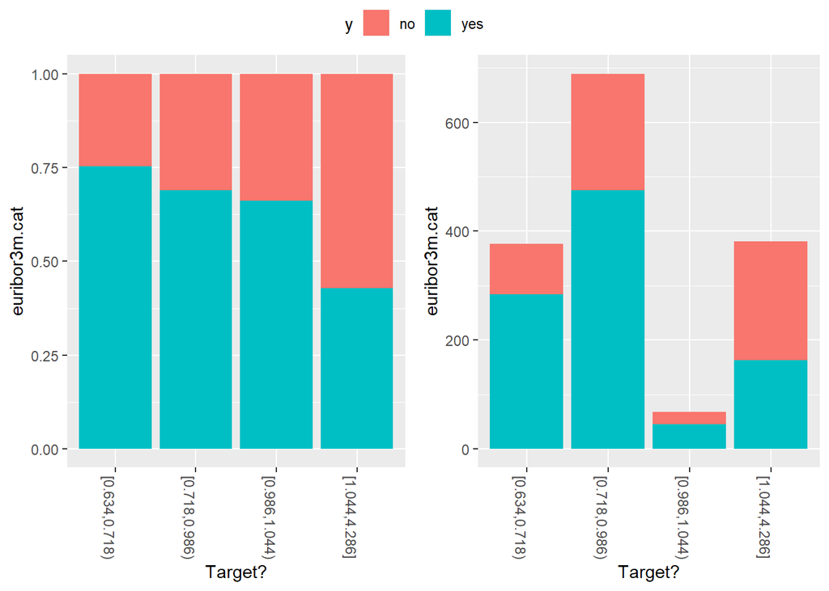

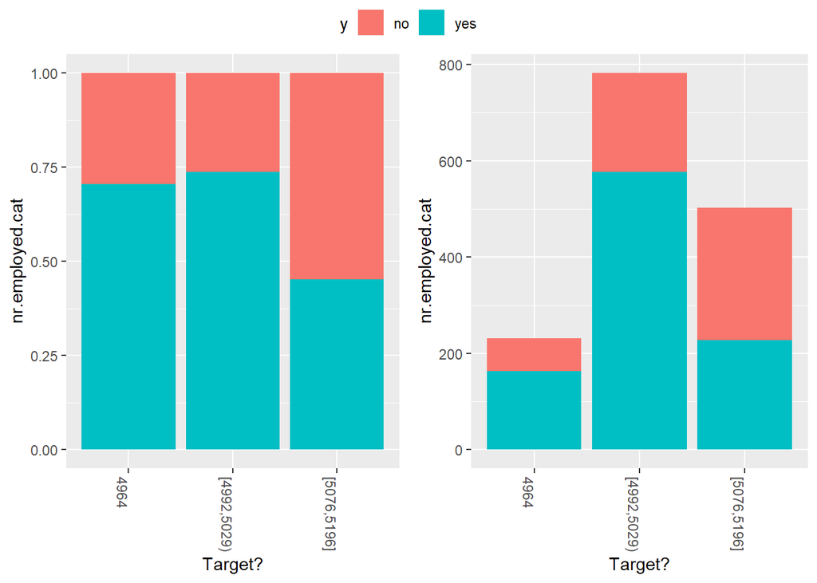

```r
data$emp.var.rate.cat = factor(cut2(data$emp.var.rate,c(-1.8,-0.1)))
data = select(data,-emp.var.rate)
for(col in c("cons.conf.idx","cons.price.idx","euribor3m","nr.employed")) {
  newCol = paste(col,".cat",sep="")
  data[[newCol]]=factor(cut2(data[,col],c(quantile(data[,col], 0.25, na.rm=TRUE)[[1]],
                                                   mean(data[,col]),
                                                   quantile(data[,col], 0.75, na.rm=TRUE)[[1]])))
  data = select(data,-col)
}

for(col in c("emp.var.rate.cat", "cons.price.idx.cat", "cons.conf.idx.cat", "euribor3m.cat", "nr.employed.cat")) {
    p1 = ggplot(data, aes(data[,col], fill = y)) + geom_bar(position="fill") +
      labs(x = "Target?", y = col) +
      theme(axis.text.x=element_text(angle = -90, hjust = 0))
    p2 = ggplot(data, aes(data[,col], fill = y)) + geom_bar() +
      labs(x = "Target?", y = col) +
      theme(axis.text.x=element_text(angle = -90, hjust = 0))
    p3 = ggarrange(p1, p2, ncol = 2, nrow = 1, common.legend = TRUE)
    print(p3)
}
```

### (3) Data outliers

Box plots were created to see if there were any outliers that should be addressed.

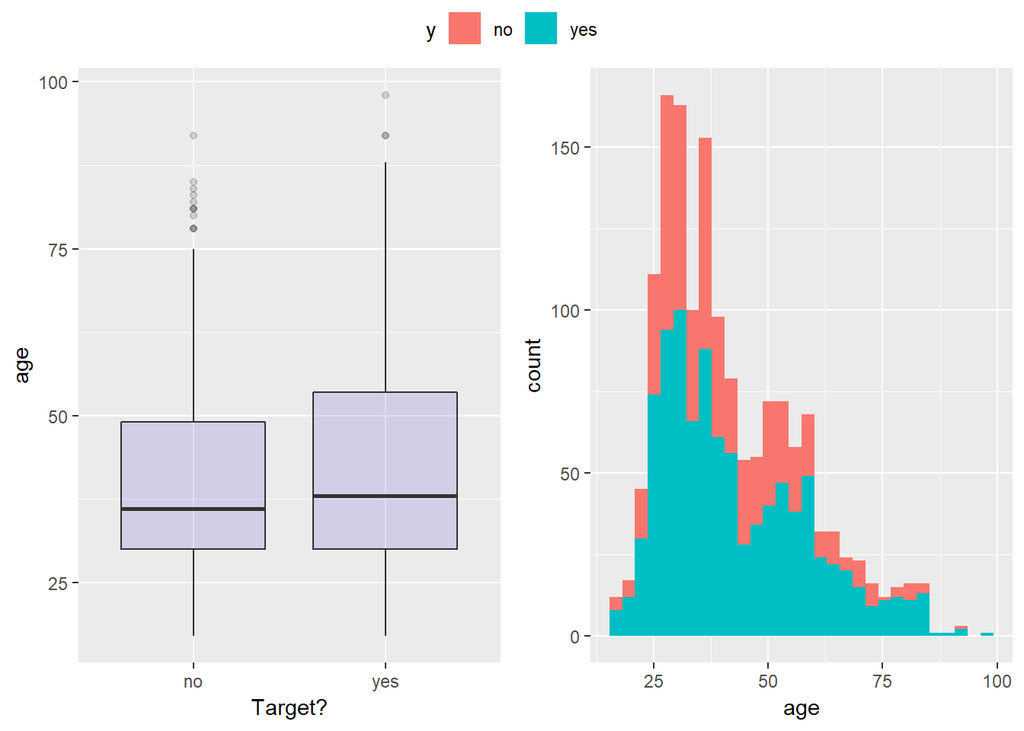

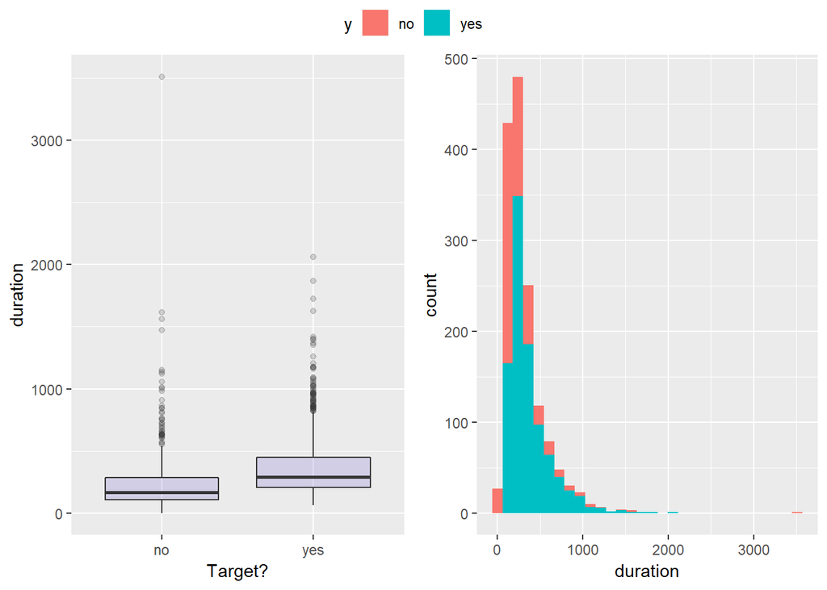

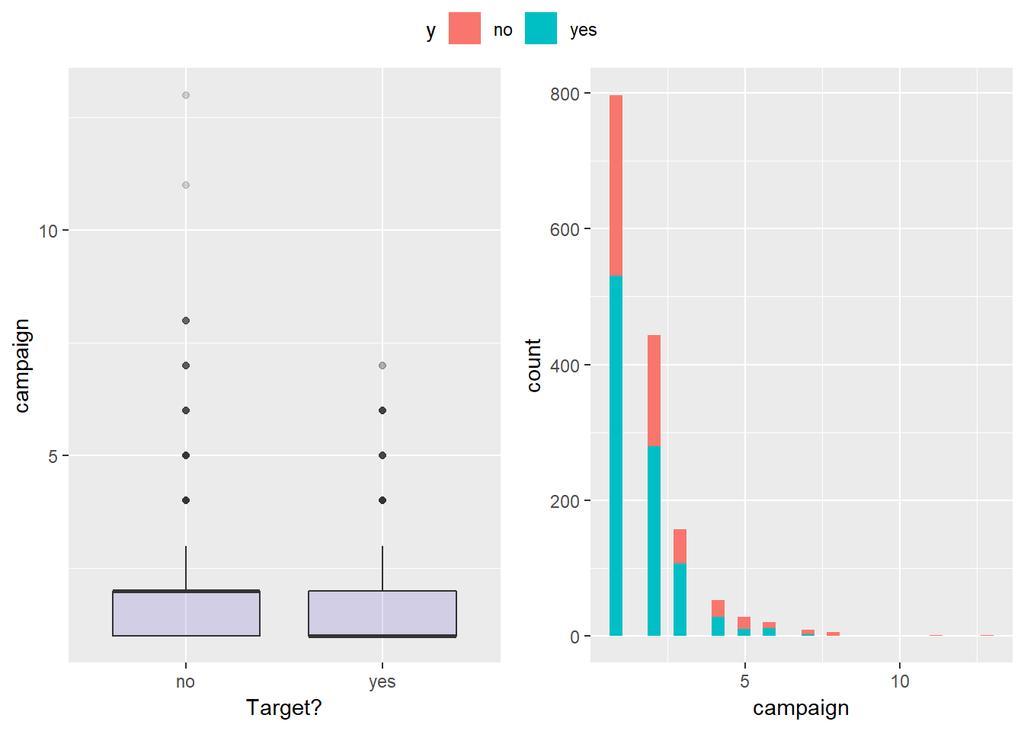

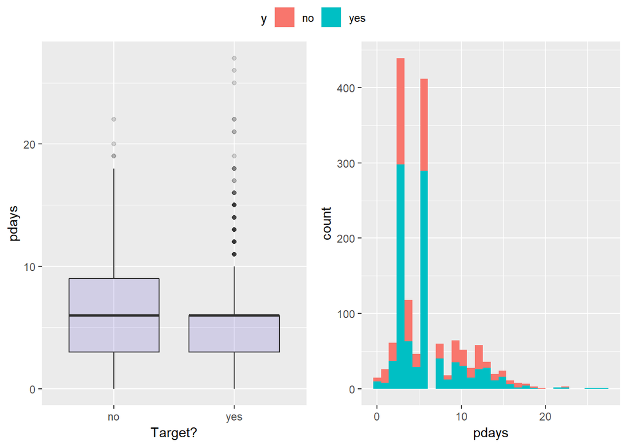

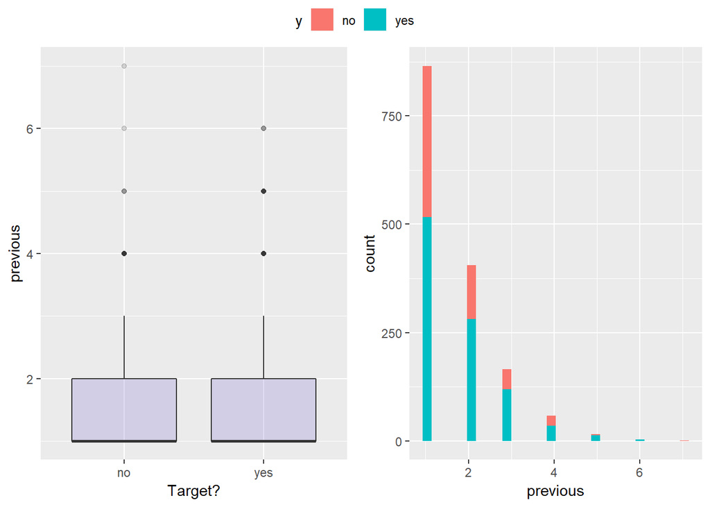

```r
# box plot for all numeric input ~ y
draw_box_plot = function() {
  for (i in 1:(length(data)-1)) {
    col = colnames(data)[i];
    if(!is.numeric(data[,i])) next
    p1 = ggplot(data, aes(x=y, y=data[,i])) +
      geom_boxplot(fill="slateblue", alpha=0.2) +
      xlab("Target?") + ylab(col)
    p2 = ggplot(data, aes(x=data[,col],fill=y)) + geom_histogram() + xlab(col)
    p3 = ggarrange(p1, p2, ncol = 2, nrow = 1, common.legend = TRUE)
    print(p3)
  }
}
draw_box_plot()
```

As can be seen in the box plots, there were no worrisome outliers to address.

### (4) Data correlations

Next we will check correlations between all the columns to see if we can find any interesting observations:

```r
# Correlation of numeric columns; need to reload data b/c we have converted some of the numeric columns to factor earlier
data=read.csv("data/bank-additional-full.csv", header = TRUE, sep = ";")
data = data[,!colnames(data) %in% c("duration") ]
library(Hmisc)
library(corrplot)
data = select(data,-y,y)
data_num=data[,sapply(data, is.numeric)]
data_num=cbind(data_num,y=as.integer(data$y))
cor_result=rcorr(as.matrix(data_num))
# Flattern
flattenCorrMatrix <- function(cormat, pmat) {
  ut <- upper.tri(cormat)
  data.frame(
    row = rownames(cormat)[row(cormat)[ut]],
    column = rownames(cormat)[col(cormat)[ut]],
    cor  =(cormat)[ut],
    p = pmat[ut]
  )
}
cor_result_flat = flattenCorrMatrix(cor_result$r, cor_result$P)
cor_result_flat = cor_result_flat[order(cor_result_flat$cor,decreasing = TRUE),]
print(cor_result_flat[cor_result_flat$column=="y",])
```

```
##               row column         cor            p
## 40       previous      y  0.23018100 0.000000e+00
## 43  cons.conf.idx      y  0.05487795 0.000000e+00
## 37            age      y  0.03039880 6.802137e-10
## 38       campaign      y -0.06635741 0.000000e+00
## 42 cons.price.idx      y -0.13621121 0.000000e+00
## 41   emp.var.rate      y -0.29833443 0.000000e+00
## 44      euribor3m      y -0.30777140 0.000000e+00
## 39          pdays      y -0.32491448 0.000000e+00
## 45    nr.employed      y -0.35467829 0.000000e+00
```

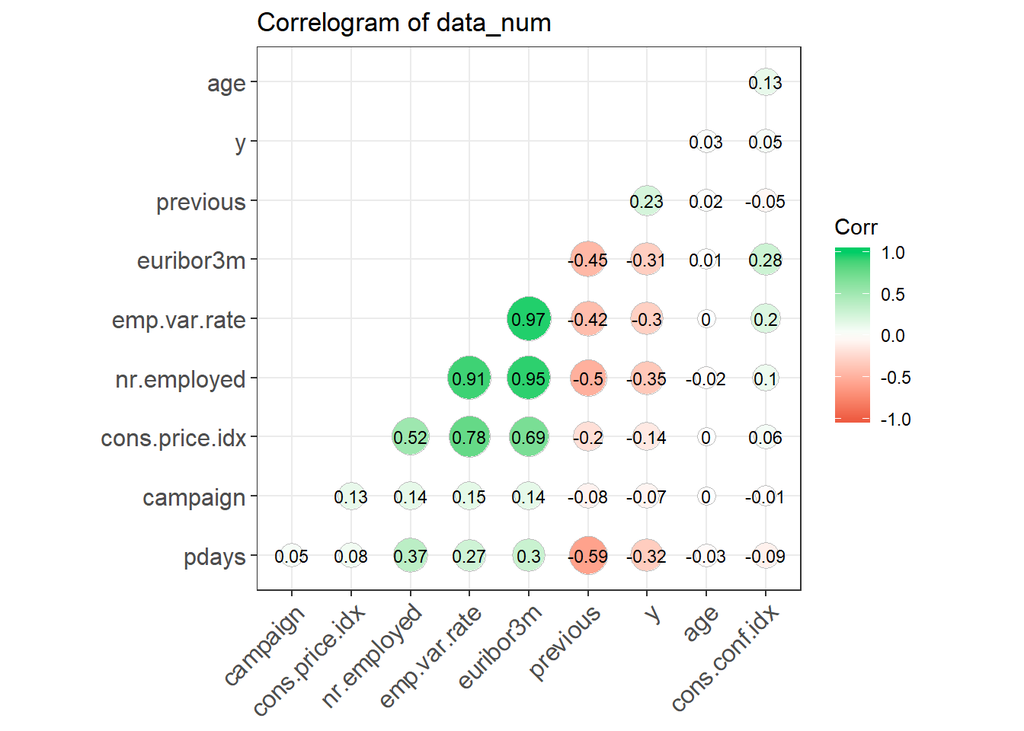

```r
library(ggcorrplot)
ggcorrplot(cor_result$r, hc.order = TRUE,
           type = "lower",
           lab = TRUE,
           lab_size = 3,
           method="circle",
           colors = c("tomato2", "white", "springgreen3"),
           title="Correlogram of data_num",
           ggtheme=theme_bw)
```

### (5) Possible inconsistencies in data

```r
## Some inconsistencies in data
data=read.csv("data/bank-additional-full.csv", header = TRUE, sep = ";") #reloading due to above code made some changed to pdays
df_pdays = data[,c("pdays","previous","poutcome")]
df_pdays = df_pdays[df_pdays$pdays==999,]
table(df_pdays$previous)
```

```
##
##     0     1     2     3     4     5     6
## 35563  3696   349    50    12     2     1
```

```r
table(df_pdays$poutcome)
```

```
##
##     failure nonexistent     success
##        4110       35563           0
```

We can see that there is a bit of inconsistency with the previous marketing campaign. Looking at all instances of “999” pdays, i.e. client was not previously contacted, there are 35,563 instances of 0 contacts performed prior to the current campaign, which lines up with the number of “nonexistent” contacts. However, there are also 4110 “failures” which have some number of prior contact attempts.

We have no way to find out what the true data is. To avoid using inconsistent data that cannot be verified, we simply consolidate pdays into a factor to show whether a client was previously contacted before or not.

```r
data$pdays_cat = factor(ifelse(data$pdays!=999,"contacted_before","not_contacted_before"))
data = select(data,-pdays)
```

### (6) Data Preprocessing

Now back to the “unknown”/“nonexistent” entries. Alghought not shown here, an experiment has been carried out to: (1) Use knn imputation to filled the missing entries for the columns that have just a few percentage of missing data; (2) Remove columns that have substantial amount of missing entries (such as “pdays”). After these two steps a glm models are fitted to see if we can get any improvements, as compared to treating “unknown” as a seperate categories.

However, we have not seen much improvements by step (1) & (2). Therefore we have decided to: (1) Just treat the “pdays” columns due to inconsistencies discovered earlier in this section; (2) Leave “unknown”/“nonexistent” as a seperate categories during modeling.

The following code documents the preprocessing done on the dataset, based on the data exploration done in this section.

```r
#reloads data and runs preparation again
data=read.csv("data/bank-additional-full.csv", header = TRUE, sep = ";")
data = data[,!colnames(data) %in% c("duration") ]
data$age_group = cut2(data$age,c(20,30,40,50,60))
data$age_group = mapvalues(data$age_group, from = levels(data$age_group), to = c("teens", "20s", "30s", "40s", "50s", "seniors"))
data = data[,colnames(data) != "age"]
data$pdays_cat = factor(ifelse(data$pdays!=999,"contacted_before","not_contacted_before"))
data = select(data,-pdays)
data$campaign_cat = factor(ifelse(data$campaign>3 , ">3",data$campaign))
data = select(data,-campaign)
data$emp.var.rate.cat = factor(cut2(data$emp.var.rate,c(-1.8,-0.1)))
data = select(data,-emp.var.rate)
for(col in c("cons.conf.idx","cons.price.idx","euribor3m","nr.employed")) {
  newCol = paste(col,".cat",sep="")
  data[[newCol]]=factor(cut2(data[,col],c(quantile(data[,col], 0.25, na.rm=TRUE)[[1]],
                                                   mean(data[,col]),
                                                   quantile(data[,col], 0.75, na.rm=TRUE)[[1]])))
  data = select(data,-col)
}
data = select(data,-y,y)
```

Split into test and train:

```r
set.seed(42)
split = createDataPartition(data$y, times = 1, p=0.25, list = F)
train = data[split,]
test = data[-split,]
train_x = train[,names(train)!="y"]
train_y = train$y
folds <- createFolds(train_y, k = 5)
myControl <- trainControl(
  summaryFunction = twoClassSummary,
  classProbs = TRUE,
  savePredictions = TRUE,
  index = folds,
  verboseIter = F
)
```

## V. Modeling

With this preparation in mind, we can now start looking at models.

### (1) Generalized Linear Model with Stepwise Feature Selection

```r
if(!exists("model_glm_stepAIC")) {
  model_glm_stepAIC <- caret::train(
  y ~ ., train,
  metric = "ROC",
  method = "glmStepAIC",
  trControl = myControl
)
}
model_glm_stepAIC
```

```
## Generalized Linear Model with Stepwise Feature Selection
##
## 10297 samples
##    19 predictor
##     2 classes: 'no', 'yes'
##
## No pre-processing
## Resampling: Bootstrapped (5 reps)
## Summary of sample sizes: 2059, 2060, 2059, 2060, 2059
## Resampling results:
##
##   ROC        Sens       Spec
##   0.7788798  0.9777277  0.2553879
```

```r
summary(model_glm_stepAIC)
```

```
##
## Call:
## NULL
##
## Deviance Residuals:
##     Min       1Q   Median       3Q      Max
## -2.0257  -0.4070  -0.3044  -0.2457   3.0713
##
## Coefficients:
##                                  Estimate Std. Error z value Pr(>|z|)
## (Intercept)                       2.84270    0.72546   3.918 8.91e-05 ***
## jobunknown                       -1.17441    0.55130  -2.130 0.033152 *
## educationuniversity.degree        0.18131    0.07843   2.312 0.020794 *
## educationunknown                  0.24410    0.16945   1.441 0.149714
## contacttelephone                 -0.67845    0.13911  -4.877 1.08e-06 ***
## monthaug                         -2.23517    0.31241  -7.155 8.39e-13 ***
## monthdec                         -1.55718    0.48174  -3.232 0.001227 **
## monthjul                         -1.52667    0.32157  -4.747 2.06e-06 ***
## monthjun                         -1.53917    0.39327  -3.914 9.09e-05 ***
## monthmay                         -2.10718    0.24068  -8.755  < 2e-16 ***
## monthnov                         -1.83146    0.35878  -5.105 3.31e-07 ***
## monthoct                         -1.36719    0.35197  -3.884 0.000103 ***
## monthsep                         -1.97190    0.35014  -5.632 1.78e-08 ***
## day_of_weekmon                   -0.26744    0.09568  -2.795 0.005188 **
## day_of_weekwed                    0.16271    0.08979   1.812 0.069980 .
## poutcomenonexistent               0.36155    0.11009   3.284 0.001023 **
## poutcomesuccess                   1.03210    0.36859   2.800 0.005109 **
## age_group20s                     -0.31081    0.11482  -2.707 0.006789 **
## age_group30s                     -0.32975    0.09386  -3.513 0.000443 ***
## age_group40s                     -0.42249    0.10876  -3.885 0.000102 ***
## pdays_catnot_contacted_before    -0.79498    0.36049  -2.205 0.027434 *
## campaign_cat1                     0.30296    0.11646   2.601 0.009286 **
## campaign_cat2                     0.40471    0.12418   3.259 0.001118 **
## campaign_cat3                     0.31151    0.14540   2.142 0.032157 *
## `cons.conf.idx.cat[-42.7,-40.5)` -1.51662    0.47693  -3.180 0.001473 **
## `cons.conf.idx.cat[-40.5,-36.4)`  0.74857    0.31237   2.396 0.016554 *
## `cons.conf.idx.cat[-36.4,-26.9]` -1.18522    0.42379  -2.797 0.005163 **
## `cons.price.idx.cat[93.1,93.6)`  -1.29875    0.24120  -5.385 7.26e-08 ***
## `cons.price.idx.cat[93.6,94.0)`  -1.14914    0.34253  -3.355 0.000794 ***
## `cons.price.idx.cat[94.0,94.8]`  -1.49305    0.30448  -4.904 9.41e-07 ***
## `euribor3m.cat[3.621,4.961)`      0.59422    0.16236   3.660 0.000252 ***
## nr.employed.cat5099              -2.63857    0.50619  -5.213 1.86e-07 ***
## `nr.employed.cat[5167,5228]`     -0.92426    0.27518  -3.359 0.000783 ***
## ---
## Signif. codes:  0 '***' 0.001 '**' 0.01 '*' 0.05 '.' 0.1 ' ' 1
##
## (Dispersion parameter for binomial family taken to be 1)
##
##     Null deviance: 7249.7  on 10296  degrees of freedom
## Residual deviance: 5589.7  on 10264  degrees of freedom
## AIC: 5655.7
##
## Number of Fisher Scoring iterations: 6
```

### (2) Classification Tree

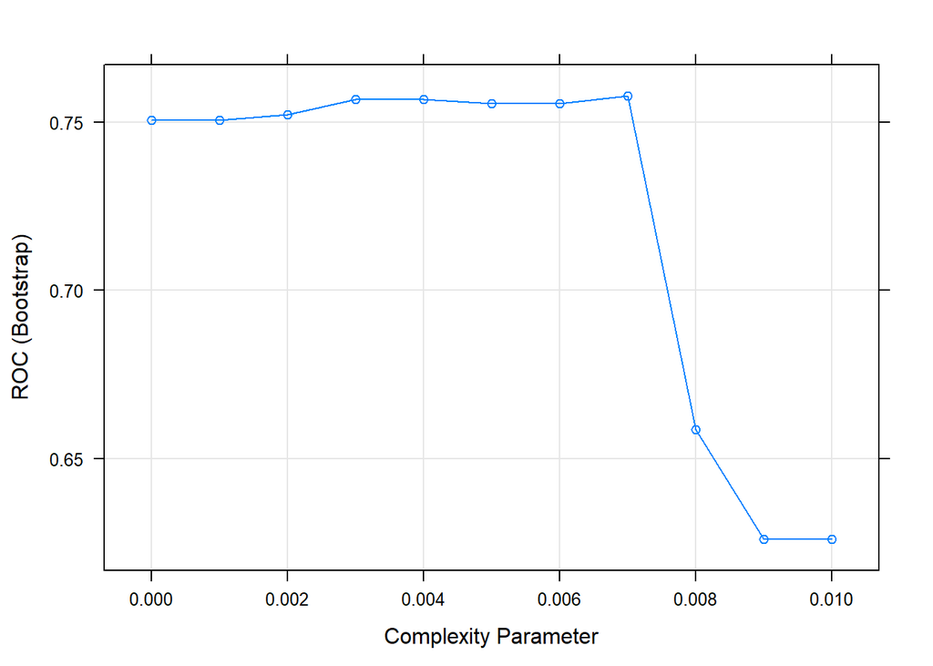

```r
if(!exists("model_rpart")) {
  model_rpart <- train(
  y ~ ., train,
  metric = "ROC",
  method = "rpart",
  trControl = myControl,
  tuneGrid = expand.grid(
    cp = seq(0,0.01,0.001)
  )
)
}
plot(model_rpart)
```

### (3) Naive Bayes

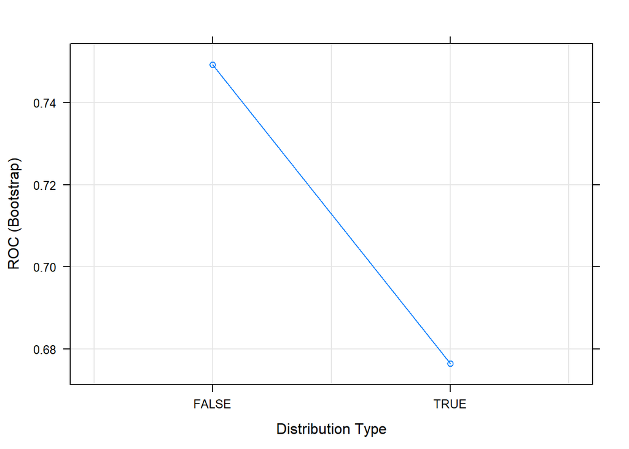

```r
if(!exists("model_nb")) {
  model_nb <- train(
  y ~ ., train,
  metric = "ROC",
  method = "naive_bayes",
  trControl = myControl
)
}
plot(model_nb)
```